# Previsão de votação de deputados

Nesse notebook vamos construir modelos preditivos de regressão em scikit learn para predição dos votos de deputados federais considerando as eleições de 2006, 2010 e prevendo para 2014.

```python
import pandas as pd
import numpy as np
import seaborn as sns
import matplotlib

import matplotlib.pyplot as plt
from scipy.stats import skew
from scipy.stats import pearsonr


%config InlineBackend.figure_format = 'retina' #set 'png' here when working on notebook
%matplotlib inline
```

```python
eleicoes_2006_2010 = pd.read_csv("eleicoes_2006_a_2010.csv")

eleicoes_2014 = pd.read_csv("eleicoes_2014.csv")
eleicoes_2014.columns = eleicoes_2006_2010.columns

all_df = pd.concat((
    eleicoes_2006_2010,
    eleicoes_2014
))

all_df["ano"] = all_df["ano"].apply(str)
all_df = all_df[all_df.votos != 0]
```

```python
all_df.head(5)
```

|  | ano | sequencial_candidato | nome | uf | partido | quantidade_doacoes | quantidade_doadores | total_receita | media_receita | recursos_de_outros_candidatos/comites | ... | quantidade_despesas | quantidade_fornecedores | total_despesa | media_despesa | cargo | sexo | grau | estado_civil | ocupacao | votos |
| --- | --- | --- | --- | --- | --- | --- | --- | --- | --- | --- | --- | --- | --- | --- | --- | --- | --- | --- | --- | --- | --- |
| 0 | 2006 | 10001 | JOSÉ LUIZ NOGUEIRA DE SOUSA | AP | PT | 6 | 6 | 16600.00 | 2766.666667 | NaN | ... | 14 | 14 | 16583.60 | 1184.542857 | DEPUTADO FEDERAL | MASCULINO | ENSINO MÉDIO COMPLETO | CASADO(A) | VEREADOR | 8579 |
| 1 | 2006 | 10002 | LOIVA DE OLIVEIRA | RO | PT | 13 | 13 | 22826.00 | 1755.846154 | 6625.0 | ... | 24 | 23 | 20325.99 | 883.738696 | DEPUTADO FEDERAL | FEMININO | SUPERIOR COMPLETO | SOLTEIRO(A) | SERVIDOR PÚBLICO ESTADUAL | 2757 |
| 2 | 2006 | 10002 | MARIA DALVA DE SOUZA FIGUEIREDO | AP | PT | 17 | 16 | 148120.80 | 9257.550000 | 2250.0 | ... | 123 | 108 | 146011.70 | 1351.960185 | DEPUTADO FEDERAL | FEMININO | SUPERIOR COMPLETO | VIÚVO(A) | PEDAGOGO | 17428 |
| 3 | 2006 | 10002 | ROMALDO MILANI | MS | PRONA | 6 | 6 | 3001.12 | 500.186667 | NaN | ... | 8 | 8 | 3001.12 | 375.140000 | DEPUTADO FEDERAL | MASCULINO | ENSINO MÉDIO INCOMPLETO | CASADO(A) | MILITAR REFORMADO | 1193 |
| 4 | 2006 | 10003 | ANSELMO DE JESUS ABREU | RO | PT | 48 | 48 | NaN | NaN | NaN | ... | 133 | 120 | 116416.64 | 970.138667 | DEPUTADO FEDERAL | MASCULINO | ENSINO FUNDAMENTAL COMPLETO | CASADO(A) | DEPUTADO | 29401 |

5 rows × 23 columns

Vamos separar dados de treino e de teste baseado no ano de eleição: 2006+2010 para treino e 2014 para teste/validação.

```python
train_df = all_df[(all_df.ano == "2006") | (all_df.ano == "2010")]
test_df = all_df[all_df.ano == "2014"]
all_data = pd.concat((
        train_df.loc[:, 'ano':'ocupacao'],
        test_df.loc[:, 'ano':'ocupacao'],
))
```

## Correções nos dados

É necessário ajustar os dados para que se adequem melhor aos procedimentos de regressão que realizaremos. Isso inclui remoção de valores NA e mudança na escala de valores enviezados (utilizando log).

```
array([[<AxesSubplot: title={'center': 'log(#doações + 1)'}>,
        <AxesSubplot: title={'center': '#doações'}>]], dtype=object)
```

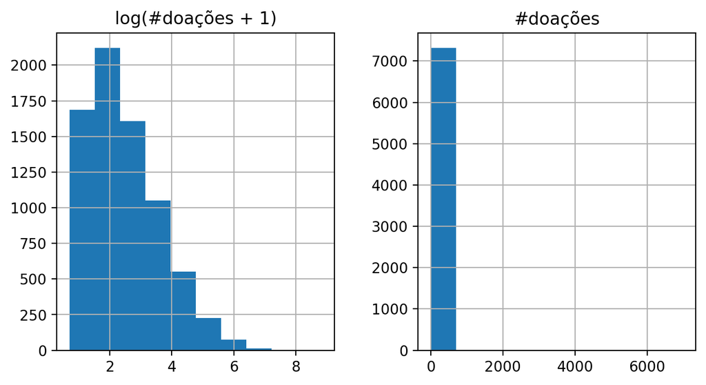

```python
matplotlib.rcParams['figure.figsize'] = (8.0, 4.0)
pd.DataFrame({
    "log(#doações + 1)": np.log1p(train_df["quantidade_doacoes"]),
    "#doações": train_df["quantidade_doacoes"]
}).hist()
```

Podemos ver que diversas variáveis são enviesadas, dado que a maioria delas reflete vantagem financeira de candidatos e distribuições de renda tendem a ser desbalanceadas. Vamos usar a escala log para normalizar esses dados.

```
array([[<AxesSubplot: title={'center': '#doações'}>,
        <AxesSubplot: title={'center': '#doadores'}>],
       [<AxesSubplot: title={'center': 'receita (R$)'}>,
        <AxesSubplot: title={'center': '#despesas'}>],
       [<AxesSubplot: title={'center': '#fornecedores'}>,
        <AxesSubplot: title={'center': 'despesa (R$)'}>]], dtype=object)
```

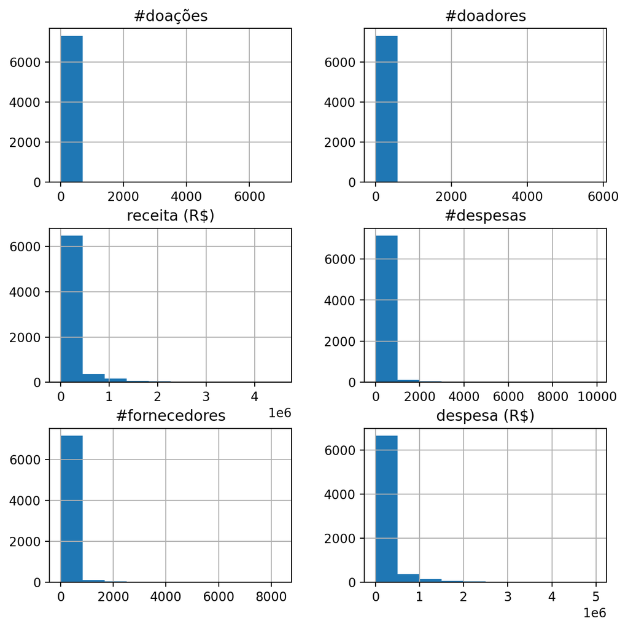

```python
matplotlib.rcParams['figure.figsize'] = (8.0, 8.0)
pd.DataFrame({
    "#doações": train_df["quantidade_doacoes"],
    "#doadores": train_df["quantidade_doadores"],
    "receita (R$)": train_df["total_receita"],
    "#despesas": train_df["quantidade_despesas"],
    "#fornecedores": train_df["quantidade_fornecedores"],
    "despesa (R$)": train_df["total_despesa"]
}).hist()
```

```python
numeric_feats = all_data.dtypes[all_data.dtypes != "object"].index

skewed_feats = train_df[numeric_feats].apply(lambda x: skew(x.dropna()))
skewed_feats = skewed_feats[skewed_feats > 0.75]
skewed_feats = skewed_feats.index

all_data[skewed_feats] = np.log1p(all_data[skewed_feats])
```

```python
# Normalizando variável categórica
train_df.votos = np.log1p(train_df.votos)

# Tratando variáveis categóricas
all_data["ano"] = all_data["ano"].apply(int)
all_data = pd.get_dummies(all_data[all_data.columns[[0] + list(range(3, 22))]])
all_data["ano"] = all_data["ano"].apply(str)
```

```python
# Substituindo NAs pela média da coluna
all_data = all_data.fillna(all_data.mean())
```

```python
# Separando grupos de treino, teste e alvo para o sklearn
X_train = all_data[(all_data.ano == "2006") | (all_data.ano == "2010")]
X_test = all_data[all_data.ano == "2014"]
y = train_df.votos
```

## Criando nosso modelo de regressão

Agora que os dados estão normalizados e tratados, podemos começar a criar modelos de regressão em cima deles. Vamos utilizar vários tipos de modelos e regularizações.

```python
from sklearn.linear_model import Ridge, LassoCV, LinearRegression
from sklearn.model_selection import cross_val_score

def rmse_cv(model):
    rmse= np.sqrt(-cross_val_score(model, X_train, y, scoring="neg_mean_squared_error", cv = 5))
    return(rmse)

def plot_residual(model):
    matplotlib.rcParams['figure.figsize'] = (6.0, 6.0)

    preds = pd.DataFrame({"preds":model.predict(X_test), "true":np.log1p(test_df.votos)})
    preds["residuals"] = preds["true"] - preds["preds"]
    preds.plot(x = "preds", y = "residuals",kind = "scatter")
```

### Sem regularização

Primeiramente vamos executar um modelo de regressão linear multivariada sem nenhuma regularização para os nossos dados.

```python
model_lr = LinearRegression().fit(X_train, y)
rmse_cv(model_lr).mean()
```

```
256456905.49804837
```

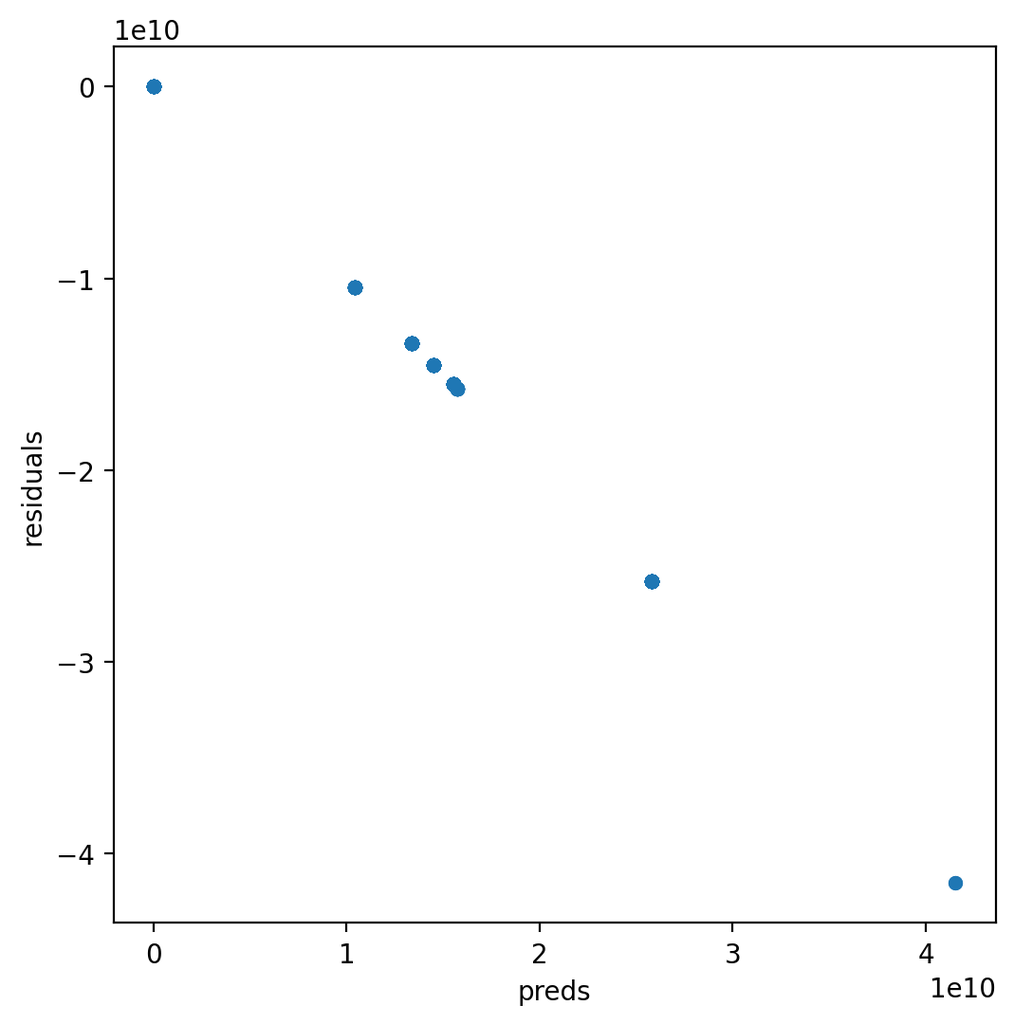

```python
plot_residual(model_lr)
```

Podemos ver tanto pelo root mean squared error (rmse = 256456905.49) altíssimo quanto pela distribuição do resíduo pelas predições que o modelo não é adequado para prever os votos como queremos. Isso é esperado dado a simplicidade desse modelo que não regulariza os coeficientes, o que é visto pela grandeza do rmse.

### Ridge

A regressão de ridge, por sua vez, já consiste em regularizar os coeficientes penalizando o quadrado desses coeficientes. Ela não lida com outliers nos dados, mas já lidamos com outliers identificados anteriormente (removendo canditados com nenhum voto).

Ridge recebe alpha como parâmetro. Variamos alguns valores possíveis para achar um msr mínimo mais efetivo.

```python
model_ridge = Ridge().fit(X_train, y)
```

```python
alphas = [0.05, 0.1, 0.3, 1, 3, 5, 10, 15, 30, 50, 75]
cv_ridge = [rmse_cv(Ridge(alpha = alpha)).mean() for alpha in alphas]
```

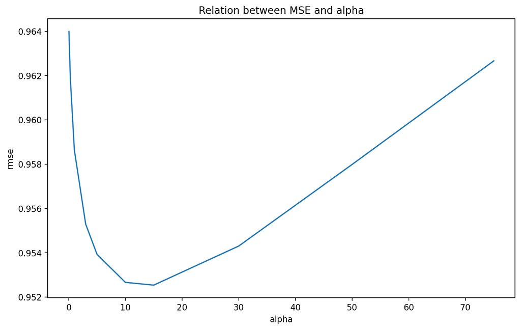

```python
matplotlib.rcParams['figure.figsize'] = (10.0, 6.0)
cv_ridge = pd.Series(cv_ridge, index = alphas)
cv_ridge.plot(title = "Relation between MSE and alpha")
plt.xlabel("alpha")
plt.ylabel("rmse")
```

```python
cv_ridge.min()
```

```
0.9525402375907941
```

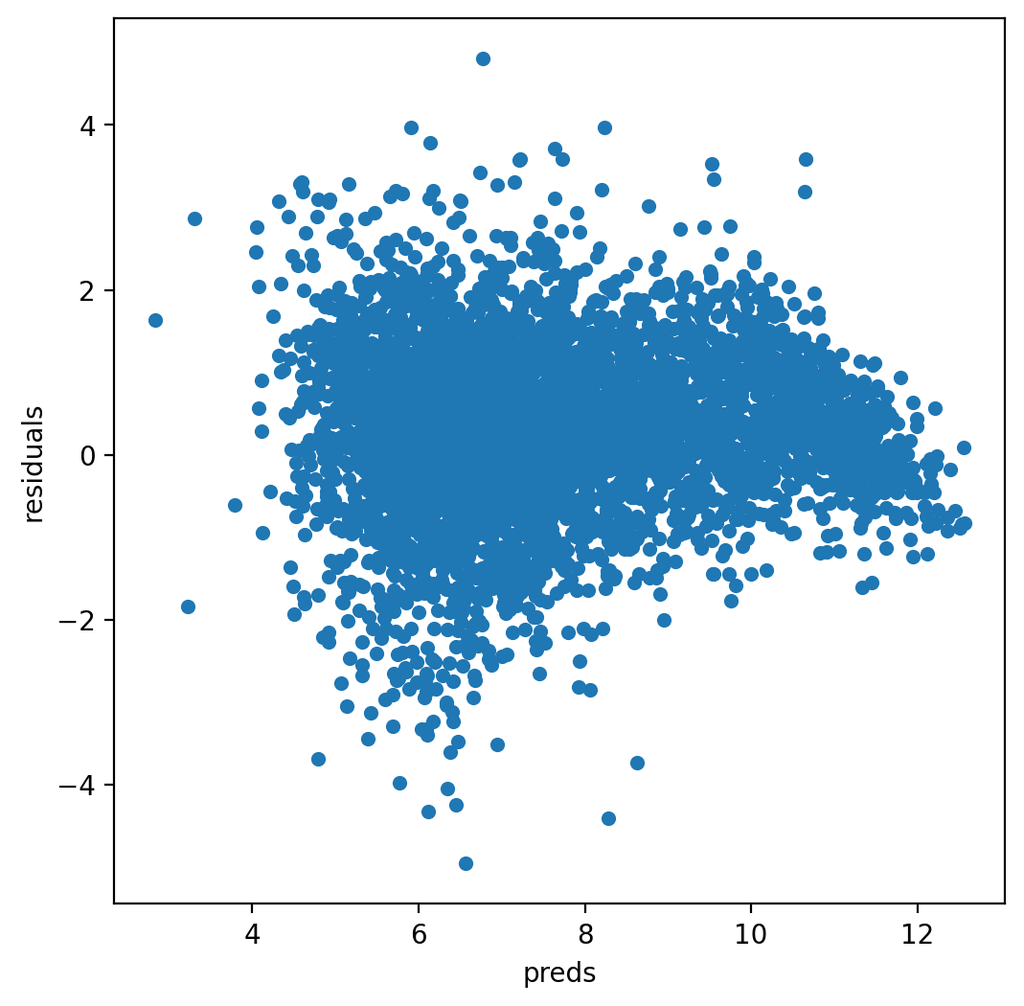

```python
plot_residual(model_ridge)
```

Dessa vez vemos que os resíduos não parecem respeitar nenhuma distribuição específica, o que indica que de fato modelos os dados que queríamos e o resíduo consiste somente do ruído natural dos dados. Queremos observar esse mesmo comportamento nos próximos modelos, que são mais preciso que a nossa primeira tentativa sem regularização.

Mesmo assim, vamos ver a seguir um pouco sobre outros modelos e seus diferenciais.

### Lasso

A regressão de Lasso também consegue regularizar o modelo, diminuindo a grandeza dos coeficientes do mesmo, porém com outra vantagem importante para aplicar em machine learning. Quando existem múltiplas features muito correlacionadas essa regularização zera o coeficiente de todas essas features exceto 1, afim de simplificar o modelo e diminuir o número de dimensões.

```python
model_lasso = LassoCV(alphas = [0.1, 1, 5, 10]).fit(X_train, y)
```

```python
coef = pd.Series(model_lasso.coef_, index = X_train.columns)
```

```python
print("Lasso picked " + str(sum(coef != 0)) + " variables and eliminated the other " +  str(sum(coef == 0)) + " variables")
```

```
Lasso picked 8 variables and eliminated the other 273 variables
```

```python
imp_coef = pd.concat([coef.sort_values().head(10),
                     coef.sort_values().tail(10)])
```

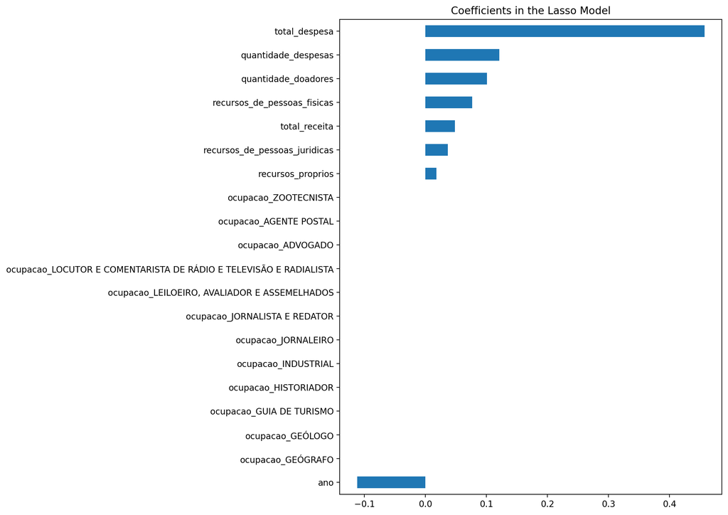

```python
matplotlib.rcParams['figure.figsize'] = (8.0, 10.0)
imp_coef.plot(kind = "barh")
plt.title("Coefficients in the Lasso Model")
```

```python
rmse_cv(model_lasso).mean()
```

```
1.067161585293425
```

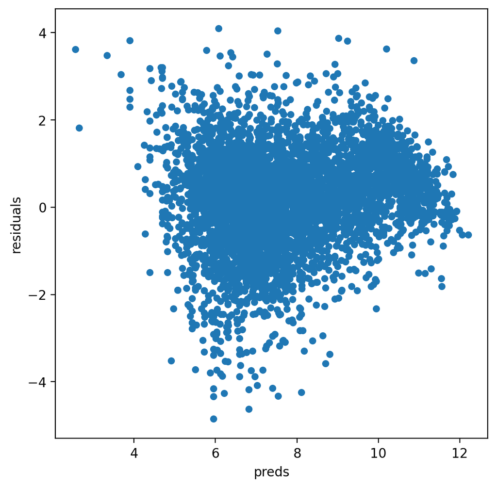

```python
plot_residual(model_lasso)
```

Assim como Ridge, vemos que Lasso conseguiu modelar o problema de forma que os resíduos representem somente ruído na amostra e que o rmse (1.0671) estivesse baixo.

### Random forest

Por último, utilizamos o modelo de regressão Random Forest. Esse modelo faz múltiplas amostragem dos dados, como bootstrapping, e usa o framework de árvores de decisão e ober resultados médios usados para prever uma variável alvo.

```python
from sklearn.ensemble import RandomForestRegressor

model_rf = RandomForestRegressor(n_estimators = 10, random_state=0).fit(X_train, y)

rmse_cv(model_rf).mean()
```

```
1.0071072395516665
```

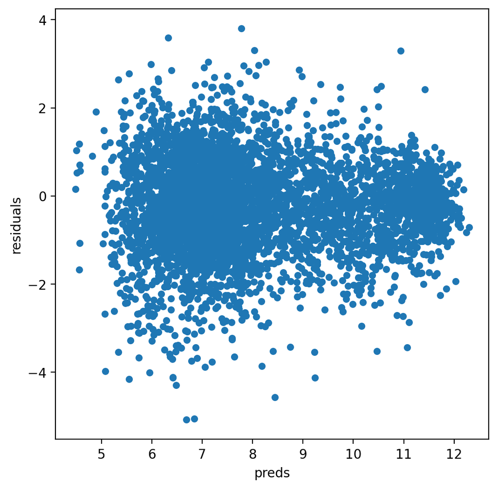

```python
plot_residual(model_rf)
```

Para esse modelo também obtivemos bons resultados de rmse (1.0071) e da distribuição dos resíduos, que parece mostrar somente o ruído que não deve ser modelado pelo nosso método de regressão.